# 102. Visit and tract metadata

For the Rubin Science Platform at data.lsst.cloud.  
Data Release: Data Preview 2  
Container Size: Large  
LSST Science Pipelines version: r29.2.0  
Last verified to run: 2026-05-01  
Repository: github.com/lsst/tutorial-notebooks  
DOI: 10.11578/rubin/dc.20250909.20

**Learning objective:** Explore and visualize the visits and tracts expected to for DP2.

**LSST data products:** Preliminary lists of visit and tract metadata for DP2.

**Packages:** `skyproj`

**Credit:** Originally developed by the Rubin Community Science team. Please cite the DOI above and consider acknowledging them if this notebook is used for the preparation of journal articles, software releases, or other notebooks.

**Get Support:** Everyone is encouraged to ask questions or raise issues in the [Support Category](https://community.lsst.org/c/support) of the Rubin Community Forum. Rubin staff will respond to all questions posted there.

## 1. Introduction

Preliminary files of visit and tract metadata for Data Preview 2 (DP2) are made available with this tutorial. The purpose of these files and this tutorial is to enable early exploration and visualization of the visits and tracts that are expected to be included in DP2. When DP2 is released, these files will be deprecated, and the visit and tract metadata will be available via queryable catalogs. A new set of tutorials will accompany the DP2 release.

**Visits:** One visit is one observation (one image; one exposure) with the LSSTCam ([lsstcam.lsst.io](https://lsstcam.lsst.io/)), centered on a sky coordinate, and obtained with a single filter and sky rotation.

**Tracts:** One tract is one square region of LSST's all-sky tesselation ("skymap"), $~1.66$ deg per side. Tracts are subdivided into 100 overlapping patches, and one deep coadd image is created per patch.

**For DP2, the total sky area covered by DP2 visits is greater than the area covered by DP2 tracts.** The total sky area over which DP2 deep coadd images would be created was defined in late 2025 to include only the Wide-Fast-Deep, Small Field Survey, and Deep Drilling Field sky regions. See the [Science Validation Survey Overview - Summary 20250930](https://survey-strategy.lsst.io/progress/sv_status/sv_20250930.html) webpage for more information about these regions. Additional visits outside of the deep coadd regions are included in DP2 as processed visit images only.

> **Caveat:** These temporary, preliminary metadata files include all visits and tracts that were initially processed, and might include those that do not ultimately pass data validation or produce science-quality data products.

### 1.1. Import packages

Import standard python packages `astropy`, `matplotlib`, and `numpy`. Import the `skyproj` package ([skyproj.readthedocs.io](https://skyproj.readthedocs.io/en/latest/)) for plotting all-sky projection plots, the `healpy` package ([healpy.readthedocs.io](https://healpy.readthedocs.io/en/latest/)) for dealing with HEALPix, and import from `lsst.utils` the standard colorblind-friendly colors for the LSST filters, $ugrizy$.

```python
from astropy.io import ascii
from astropy.time import Time
from astropy.coordinates import SkyCoord
from astropy.wcs import WCS
from regions import PolygonSkyRegion
import matplotlib.pyplot as plt
import numpy as np
import skyproj
import healpy as hp
from lsst.utils.plotting import (get_multiband_plot_colors,
                                 get_multiband_plot_linestyles)
```

### 1.2. Define parameters

Define the colors and linestyles to use for each of the LSST filters.

```python
filter_colors = get_multiband_plot_colors()
filter_names = list(filter_colors.keys())
filter_linestyles = get_multiband_plot_linestyles()
```

Define the path to the data files used in this tutorial.

```python
file_path = '/rubin/cst_repos/tutorial-notebooks-data/data/'
```

**Option**: to create interactive plots with zoom-in capabilities, un-comment and execute the following cell. All plots created after this will be interactive. To return to static plots, comment-out this cell, restart the kernel and clear all outputs, and re-execute the cells of this notebook.

```python
# %matplotlib widget
```

## 2. Visits

The file `dp2_visits_table.ecsv` contains a preliminary, temporary table of visits that will be included in DP2.

Column names, descriptions, and units.

- `visitId`: A unique long integer identifier, composed of the year-month-day and a sequential image number.
- `band`: The LSST filter. One of $ugrizy$.
- `ra`: Right Ascension, in degrees.
- `dec`: Declination, in degrees.
- `skyRotation`: Camera rotation in degrees east of north.
- `azimuth`: Telescope pointing azimuth, in degrees.
- `altitude`: Telescope pointing altitude, in degrees.
- `zenithDistance`: Telescope pointing distance from zenith, in degrees.
- `airmass`: Airmass of the telescope pointing.
- `expTime`: Exposure time, in seconds.
- `expMidptMJD`: Time at the middle of the exposure, in modified Julian date (MJD).
- `obsStartMJD`: Time at the start of the exposure, in MJD.
- `mean_seeing`: Initial estimate of seeing, averaged over all detectors, in arcseconds.
- `mean_maglim`: Initial estimate of PSF magnitude limit, averaged over all detectors, in mags.

### 2.1. Read the visits table

Read the prepared file of visit metadata, print the total number of rows (visits), and display the first five rows of the table.

```python
visits_table = ascii.read(file_path + 'dp2_visits_table_with_iq.ecsv')
print('Number of visits: ', len(visits_table))
visits_table[:5]
```

```
Number of visits:  28698
```

*Table length=5*

| visitId int64 | band str1 | ra float64 | dec float64 | skyRotation float64 | azimuth float64 | altitude float64 | zenithDistance float64 | airmass float64 | expTime float64 | expMidptMJD float64 | obsStartMJD float64 | mean_seeing float64 | mean_maglim float64 |
| --- | --- | --- | --- | --- | --- | --- | --- | --- | --- | --- | --- | --- | --- |
| 2025042400172 | r | 185.443060811076 | 5.98102138504802 | 146.113088289607 | 1.9614440076983797 | 53.8990970549479 | 36.1009029450521 | 1.23704795139999 | 29.999915599823 | 60790.11722739659 | 60790.11705378597 | 1.3717809522436122 | 23.90346908569336 |
| 2025042400173 | r | 187.349245626471 | 8.23604638508455 | 144.18450391305 | 4.59267468721633 | 51.5610973958556 | 38.4389026041444 | 1.27595524322485 | 30.0000872612 | 60790.1177404311 | 60790.117566819485 | 1.360464795099889 | 23.798002243041992 |
| 2025042400174 | r | 186.443750064719 | 7.16885705640284 | 138.496645426916 | 2.93858842208796 | 52.6885249328851 | 37.3114750671149 | 1.2566323773581 | 30.0009806156158 | 60790.11824723747 | 60790.11807362069 | 1.357174265291119 | 23.803224563598633 |
| 2025042400175 | r | 185.542702196852 | 6.0999042479778 | 132.754022698538 | 1.19423996978959 | 53.7910062641441 | 36.2089937358559 | 1.23874981794006 | 30.0010826587677 | 60790.118757722914 | 60790.118584105534 | 1.2905303859739274 | 23.877490997314453 |
| 2025042400176 | r | 187.450364693337 | 8.35450149584232 | 130.813892358106 | 3.8613155396456 | 51.471714859197 | 38.528285140803 | 1.27753357366488 | 30.0010211467743 | 60790.11927441511 | 60790.11910079809 | 1.390931531603405 | 23.81049156188965 |

### 2.2. Exposure times

The exposure times in column `expTime` are in seconds. For filters $grizy$, the *standard* exposure time is 30 seconds, whereas for $u$-band it is 38 seconds.

Create a stacked bar plot of the exposure time distribution by filter.

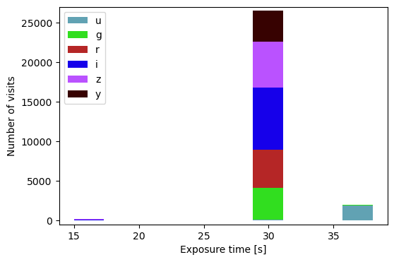

```python
xvals = []
clrs = []
lbls = []
for filt in filter_names:
    tx = np.where(visits_table['band'] == filt)[0]
    if len(tx) > 0:
        xvals.append(visits_table['expTime'][tx])
        clrs.append(filter_colors[filt])
        lbls.append(filt)
fig = plt.figure(figsize=(6, 4))
plt.hist(xvals, 10, histtype='bar', stacked=True, facecolor=clrs, label=lbls)
plt.legend(loc='upper left')
plt.ylim([-500, 27000])
plt.xlabel('Exposure time [s]')
plt.ylabel('Number of visits')
plt.show()
del xvals, clrs, lbls
```

> **Figure 1:** Stacked bar chart of exposure times per visit, by filter.

Although it is clear from the plot above that *most* visits with exposure times >30s are in the $u$-band, it is unclear which other filters have visits with shorter or longer exposure times. The bin width furthermore makes it unclear whether all exposure times are exactly the same, or if there is scatter within a bin.

For visits with 30s, <30s, and >30s exposure time, print the mean and standard deviation in the exposure time, and the number of visits per filter.

```python
tx1 = np.where((visits_table['expTime'] < 29))[0]
tx2 = np.where((visits_table['expTime'] >= 29) & (visits_table['expTime'] <= 31))[0]
tx3 = np.where((visits_table['expTime'] > 31))[0]
print(f"{'exposure time': <15} {' mean': <4}  {'std': <3}")
print(f"{'<29 s ': <15} {np.round(np.mean(visits_table['expTime'][tx1]), 1): 4.1f}  "
      f"{np.round(np.std(visits_table['expTime'][tx1]), 1): 3.1f}")
print(f"{' 30 s ': <15} {np.round(np.mean(visits_table['expTime'][tx2]), 1): 4.1f}  "
      f"{np.round(np.std(visits_table['expTime'][tx2]), 1): 3.1f}")
print(f"{'>31 s ': <15} {np.round(np.mean(visits_table['expTime'][tx3]), 1): 4.1f}  "
      f"{np.round(np.std(visits_table['expTime'][tx3]), 1): 3.1f}")
print(' ')
vals1 = ['<29 s ']
vals2 = [' 30 s ']
vals3 = ['>31 s ']

for filt in filter_names:
    vals1.append(len(np.where(visits_table['band'][tx1] == filt)[0]))
    vals2.append(len(np.where(visits_table['band'][tx2] == filt)[0]))
    vals3.append(len(np.where(visits_table['band'][tx3] == filt)[0]))
print(f"{'exposure time': <15} {'u': <4}  {'g': <4}  {'r': <4}  {'i': <4}  {'z': <4}  {'y': <4}")
print(f"{vals1[0]: <15} {vals1[1]: <4}  {vals1[2]: <4}  {vals1[3]: <4}  "
      f"{vals1[4]: <4}  {vals1[5]: <4}  {vals1[6]: <4}")
print(f"{vals2[0]: <15} {vals2[1]: <4}  {vals2[2]: <4}  {vals2[3]: <4}  "
      f"{vals2[4]: <4}  {vals2[5]: <4}  {vals2[6]: <4}")
print(f"{vals3[0]: <15} {vals3[1]: <4}  {vals3[2]: <4}  {vals3[3]: <4}  "
      f"{vals3[4]: <4}  {vals3[5]: <4}  {vals3[6]: <4}")
```

```
exposure time    mean  std
<29 s            15.0   0.0
 30 s            30.0   0.0
>31 s            38.0   0.0

exposure time   u     g     r     i     z     y
<29 s           0     14    0     85    49    0
 30 s           63    4058  4848  7870  5760  3944
>31 s           1901  94    8     4     0     0
```

### 2.3. MJD distribution

Plot the cumulative distribution of the modified Julian dates (MJDs) at the midpoint time of all exposures (use the `expMidptMJD` column).

Define a few "notable dates" to mark on the figure (see caption), then create a plot of the cumulative number of visits over time.

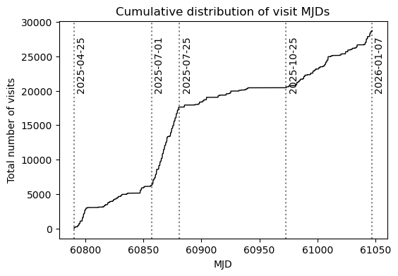

```python
notable_mjds = [np.floor(np.min(visits_table['expMidptMJD'])),
                60857, 60881, 60973,
                np.floor(np.max(visits_table['expMidptMJD']))]
fig = plt.figure(figsize=(6, 4))
for i, mjd in enumerate(notable_mjds):
    plt.axvline(mjd, ls='dotted', color='grey')
    t = Time(mjd, format='mjd', scale='utc')
    s = str(t.to_datetime())
    plt.text(mjd+2, 20000, s[0:10], rotation=90)
    del t, s
plt.plot(np.sort(visits_table['expMidptMJD']), np.arange(len(visits_table)),
         ls='solid', lw=1, color='black')
plt.xlabel('MJD')
plt.ylabel('Total number of visits')
plt.title('Cumulative distribution of visit MJDs')
plt.show()
```

> **Figure 2:** The cumulative distribution of visit MJDs (modified Julian dates) for all visits, for all filters combined. Notable dates are marked with vertical dotted lines: the start (Apr 25 2025) and end (Jan 07 2026) of the data collection window; a phase of rapid data acquisition (July 01-25 2025); and the end of the engineering shutdown (Oct 25 2025).

Plot the binned cumulative distribution of MJDs for each filter.

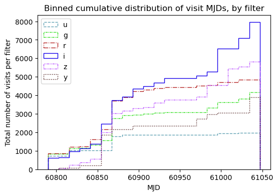

```python
fig = plt.figure(figsize=(6, 4))
for f, filt in enumerate(filter_names):
    tx = np.where(visits_table['band'] == filt)[0]
    plt.hist(visits_table['expMidptMJD'][tx], histtype='step', bins=20,
             range=(notable_mjds[0], notable_mjds[-1]), cumulative=True,
             linestyle=filter_linestyles[filt], color=filter_colors[filt], label=filt)
    del tx
plt.legend(loc='upper left')
plt.xlabel('MJD')
plt.ylabel('Total number of visits per filter')
plt.title('Binned cumulative distribution of visit MJDs, by filter')
plt.show()
```

> **Figure 3:** The binned cumulative distribution of visit MJDs by filter (see figure legend).

### 2.4. Airmass distribution

Plot the cumulative distribution of airmasses for all visits (use the `airmass` column).

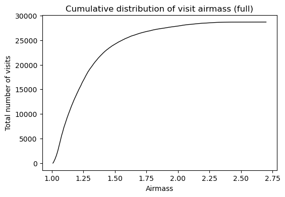

```python
fig = plt.figure(figsize=(6, 4))
plt.plot(np.sort(visits_table['airmass']), np.arange(len(visits_table)),
         ls='solid', lw=1, color='black')
plt.xlabel('Airmass')
plt.ylabel('Total number of visits')
plt.title('Cumulative distribution of visit airmass (full)')
plt.show()
```

> **Figure 4:** The cumulative distribution of visit airmass for all visits, for all filters combined.

Plot the binned cumulative distribution of airmasses for each filter.

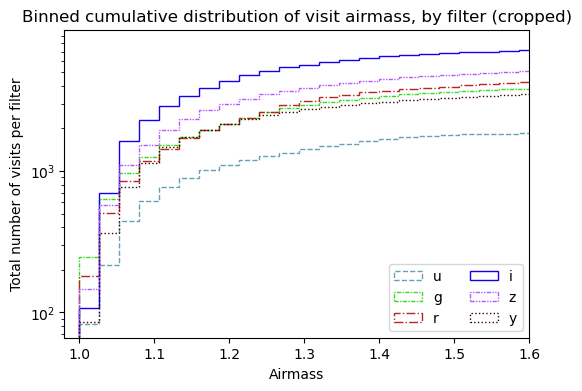

```python
fig = plt.figure(figsize=(6, 4))
for f, filt in enumerate(filter_names):
    tx = np.where(visits_table['band'] == filt)[0]
    plt.hist(visits_table['airmass'][tx], histtype='step', bins=75,
             range=(1.0, 3.0), cumulative=True, log=True,
             linestyle=filter_linestyles[filt], color=filter_colors[filt], label=filt)
    del tx
plt.legend(loc='best', ncol=2)
plt.xlim([0.98, 1.6])
plt.xlabel('Airmass')
plt.ylabel('Total number of visits per filter')
plt.title('Binned cumulative distribution of visit airmass, by filter (cropped)')
plt.show()
```

> **Figure 5:** The binned cumulative distribution of visit airmass by filter (see figure legend). The x-axis has been cropped to show only airmass $\leq 1.6$.

### 2.5. Initial IQ estimates

Plot the initial estimates of seeing and magnitude limit, averaged over all detectors, per visit per filter.

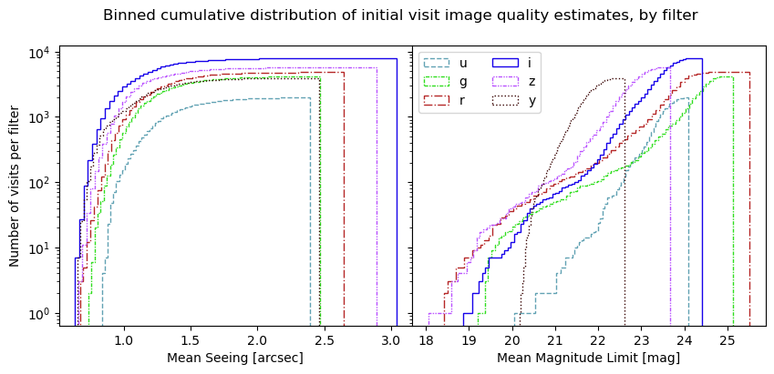

```python
fig, ax = plt.subplots(1, 2, figsize=(10, 4), sharey=True)
for f, filt in enumerate(filter_names):
    tx = np.where(visits_table['band'] == filt)[0]
    ax[0].hist(visits_table['mean_seeing'][tx], histtype='step', bins=75,
               cumulative=True, log=True,
               linestyle=filter_linestyles[filt], color=filter_colors[filt], label=filt)
    ax[1].hist(visits_table['mean_maglim'][tx], histtype='step', bins=75,
               cumulative=True, log=True,
               linestyle=filter_linestyles[filt], color=filter_colors[filt], label=filt)
    del tx
ax[1].legend(loc='upper left', ncol=2)
ax[0].set_xlabel('Mean Seeing [arcsec]')
ax[1].set_xlabel('Mean Magnitude Limit [mag]')
ax[0].set_ylabel('Number of visits per filter')
plt.subplots_adjust(wspace=0)
plt.suptitle('Binned cumulative distribution of initial visit image quality estimates, by filter')
plt.show()
```

> **Figure 6:** The binned cumulative distribution of initial estimates for the mean seeing (left) and mean magnitude limit (right) per visit (averaged over all detectors), by filter.

### 2.6. Sky distribution

Use the `healpy` package to print the area of one 19-sided HEALPix. It is similar to the LSSTCam field of view (FOV) of 9.6 square degrees.

```python
print('One 19-sided HEALPix is ', np.round(hp.nside2pixarea(19, degrees=True), 2),
      ' square degrees.')
print('It takes ', int(41253.0 / hp.nside2pixarea(19, degrees=True)),
      ' 19-sided HEALPix to cover the full sky.')
```

```
One 19-sided HEALPix is  9.52  square degrees.
It takes  4332  19-sided HEALPix to cover the full sky.
```

Create a two-dimensional (2D) histogram of the visits on the sky, for all filters together. Use 19-sided HEALPix to approximately match the area of one visit on the sky.

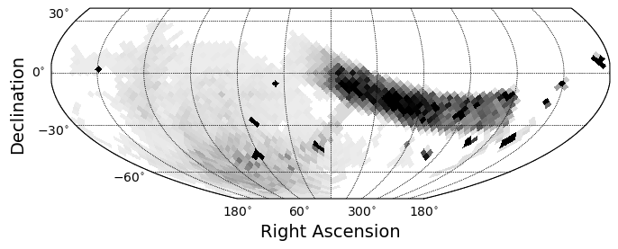

```python
fig, ax = plt.subplots(figsize=(8, 6))
sp = skyproj.McBrydeSkyproj(ax=ax)
vras = np.asarray(visits_table['ra'], dtype='float')
vdecs = np.asarray(visits_table['dec'], dtype='float')
sp.draw_hpxbin(vras, vdecs, nside=19, alpha=1, cmap='Greys', vmin=-10)
sp.ax.set_xlabel("Right Ascension", fontsize=14)
sp.ax.set_ylabel("Declination", fontsize=14)
plt.show()
```

> **Figure 7:** A 2D histogram illustrating the distribution of DP2 visits on the sky (for all filters, combined).

Print the approximate total sky area covered by visits.

```python
hpx_bins = sp.draw_hpxbin(vras, vdecs, nside=19)
array = hpx_bins[0]
tx = np.where(array > 0)[0]
print('Number of HEALPix with non-zero visits: ', len(tx))
print('Approximate area of all DP2 visits: ', int(len(tx) * hp.nside2pixarea(19, degrees=True)),
      ' square degrees.')
del sp, vras, vdecs, hpx_bins, array, tx
```

```
Number of HEALPix with non-zero visits:  1633
Approximate area of all DP2 visits:  15550  square degrees.
```

Show a similar 2D histogram as above, but only for the g-band filter, and use the "Greens" [colormap](https://matplotlib.org/stable/gallery/color/colormap_reference.html).

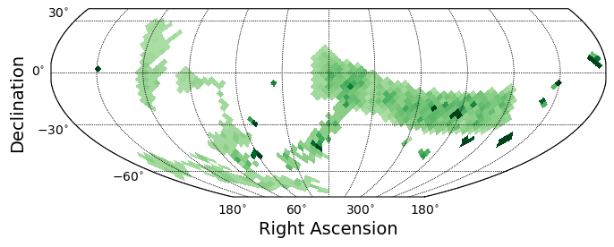

```python
show_filter = 'g'
use_colormap = 'Greens'
fig, ax = plt.subplots(figsize=(8, 6))
sp = skyproj.McBrydeSkyproj(ax=ax)
tx = np.where(visits_table['band'] == show_filter)[0]
vras = np.asarray(visits_table['ra'][tx], dtype='float')
vdecs = np.asarray(visits_table['dec'][tx], dtype='float')
sp.draw_hpxbin(vras, vdecs, nside=19, alpha=1, cmap=use_colormap, vmin=-10)
sp.ax.set_xlabel("Right Ascension", fontsize=14)
sp.ax.set_ylabel("Declination", fontsize=14)
plt.show()
del sp, tx, vras, vdecs, show_filter, use_colormap
```

Instead of a 2D histogram, the cell below offers the option to mark each visit as a separate, semi-transparent marker the size of the LSSTCam FOV on the sky (radius ~1.75 deg).

> **Warning:** The mode of plotting in the following cell takes a few minutes to render, is not as informative as a histogram, and will not scale well as the number of visits increases. But it is possible, as there are only ~28,000 visits of DP2. If the matplotlib widget for interactive plots has been enabled, the plot will still display but it will not zoom smoothly.

```python
# fig, ax = plt.subplots(figsize=(8, 6))
# sp = skyproj.McBrydeSkyproj(ax=ax)
# vras = np.asarray(visits_table['ra'], dtype='float')
# vdecs = np.asarray(visits_table['dec'], dtype='float')
# for ra, dec in zip(vras, vdecs):
#     sp.ax.circle(ra, dec, 1.75, edgecolor=None, color='grey', alpha=0.1, fill=True)
# plt.show()
# del sp, vras, vdecs
```

## 3. Tracts

The file `dp2_tracts_table.ecsv` contains a preliminary, temporary table of tracts that will have at least one patch with a deep coadd image in DP2.

Column names, descriptions, and units.

- `tractId`: A unique integer identifier; the tract number.
- `filters_list`: A string of up to six characters containing the filters with a deep coadd image in the tract (e.g., `gi`, `ugr`, `ugrizy`).
- `vertices_deg`: A list of the sky coordinates for the tract's four corners. For north-up east-left alignment (RA increases left), the order of the corners are: south-east (lower-left), south-west (lower-right), north-west (upper-right), north-east (upper-left).
- `psf_maglim`: The $5\sigma$ PSF magnitude limit in the $r$ and $i$ bands, in AB magnitudes.
- `psf_size`: The PSF characteristic width as computed from the determinant radius, in the $r$ and $i$ bands, in pixels.

The two image quality (IQ) parameters, the magnitude limit and PSF size, are evaluated from the survey property maps at the center of the tract:

- `deepCoadd_psf_maglim_consolidated_map_weighted_mean`
- `deepCoadd_psf_size_consolidated_map_weighted_mean`

The `psf_size` is the $\sigma$ in pixels, and can be approximately converted to arcseconds with a pixel scale of $\sim0.2$ arcsec/pixel. To convert the `psf_size` to a FWHM in arcseconds, use: $FWHM = 0.2 \sigma \times 2 \sqrt{2 \ln(2)} = 2.3548 \times 0.2 \sigma$

### 3.1. Read the tracts table

Read the prepared file of tract metadata. Print the total number of rows (tracts) and an upper limit on the total sky area covered.

```python
tracts_table = ascii.read(file_path + 'dp2_tracts_table_with_iq.ecsv')
print('Number of deep coadd tracts: ', len(tracts_table))
print('Maximum sky area covered by deep coadd tracts: ', int(len(tracts_table) * 1.66**2),
      ' square degrees.')
```

```
Number of deep coadd tracts:  2193
Maximum sky area covered by deep coadd tracts:  6043  square degrees.
```

> **Caveat:** The maximum sky area covered by deep coadd tracts is an upper limit for two reasons. One, all tracts overlap and these overlap areas have not been accounted for. Two, a tract will be included in the file even if only one of its 100 patches has a deep coadd image.

Print the number of tracts covered by all six filters, $ugrizy$, and the sky area covered. This is also an upper limit.

```python
tx = np.where(tracts_table['filters_list'] == 'ugrizy')[0]
print('Number of deep coadd tracts with ugrizy: ', len(tx))
print('Maximum sky area covered: ', int(len(tx) * 1.66**2), ' square degrees.')
del tx
```

```
Number of deep coadd tracts with ugrizy:  1244
Maximum sky area covered:  3427  square degrees.
```

Display the first five rows of the table.

```python
tracts_table[:5]
```

*Table length=5*

| tractId int64 | filters_list str6 | vertices_deg float64[4,2] | psf_maglim_r float64 | psf_size_r float64 | psf_maglim_i float64 | psf_size_i float64 |
| --- | --- | --- | --- | --- | --- | --- |
| 2054 | gi | 1.3578396241683794 .. -50.481666831124706 | nan | nan | nan | nan |
| 2055 | gi | 3.695501961830713 .. -50.481666831124706 | nan | nan | 22.74056826049059 | 3.4460980395425973 |
| 2056 | gi | 6.033164299493053 .. -50.481666831124706 | nan | nan | 22.548426447647294 | 3.485872864308098 |
| 2057 | gi | 8.370826637155393 .. -50.4816668311247 | nan | nan | 22.704788096643394 | 3.643065677369538 |
| 2058 | gi | 10.708488974817731 .. -50.481666831124706 | nan | nan | 22.43389261906287 | 3.4671865722720625 |

### 3.2. Coverage by filter

Print the total number (and fraction) of tracts with deep coadd images for each filter.

```python
for filt in filter_names:
    tally = 0
    for flist in tracts_table['filters_list']:
        if flist.find(filt) >= 0:
            tally += 1
    print(filt, tally, np.round(tally/len(tracts_table), 2))
del tally
```

```
u 1416 0.65
g 1799 0.82
r 2010 0.92
i 2031 0.93
z 1891 0.86
y 1596 0.73
```

Some tracts are not fully filled by deep coadd images, and have a `nan` value for the PSF magnitude limit or PSF size. Print the total number (and fraction) of $r$- and $i$-band tracts that have sufficient data for the PSF magnitude limit to be estimated.

```python
for filt in ['r', 'i']:
    tally = 0
    tally2 = 0
    for f, flist in enumerate(tracts_table['filters_list']):
        if flist.find(filt) >= 0:
            tally += 1
            if np.isfinite(tracts_table['psf_maglim_' + filt][f]):
                tally2 += 1
    print(filt, tally, tally2, np.round(tally2/tally, 2))
del tally
```

```
r 2010 1536 0.76
i 2031 1594 0.78
```

### 3.3. IQ parameters

Plot histograms of the tract image quality (IQ) parameters provided in the table.

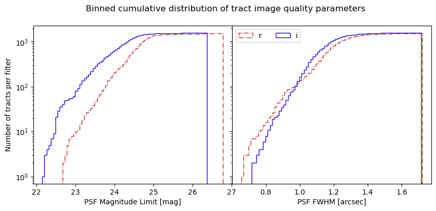

```python
fig, ax = plt.subplots(1, 2, figsize=(10, 4), sharey=True)
for f, filt in enumerate(['r', 'i']):
    tx1 = np.where(np.isfinite(tracts_table['psf_maglim_' + filt]))[0]
    tx2 = np.where(np.isfinite(tracts_table['psf_size_' + filt]))[0]
    ax[0].hist(tracts_table['psf_maglim_' + filt][tx1], histtype='step',
               bins=75, cumulative=True, log=True,
               linestyle=filter_linestyles[filt], color=filter_colors[filt], label=filt)
    ax[1].hist(0.2 * 2.3548 * tracts_table['psf_size_' + filt][tx2], histtype='step',
               bins=75, cumulative=True, log=True,
               linestyle=filter_linestyles[filt], color=filter_colors[filt], label=filt)
    del tx1, tx2
ax[1].legend(loc='upper left', ncol=2)
ax[0].set_xlabel('PSF Magnitude Limit [mag]')
ax[1].set_xlabel('PSF FWHM [arcsec]')
ax[0].set_ylabel('Number of tracts per filter')
plt.subplots_adjust(wspace=0)
plt.suptitle('Binned cumulative distribution of tract image quality parameters')
plt.show()
```

> **Figure 9:** The binned cumulative distribution of tract IQ parameters, the PSF magnitude limit (left) and the PSF FWHM (right) in the $r$- and $i$-filters.

### 3.4. Sky distribution

Use the tract vertices to draw one polygon per tract.

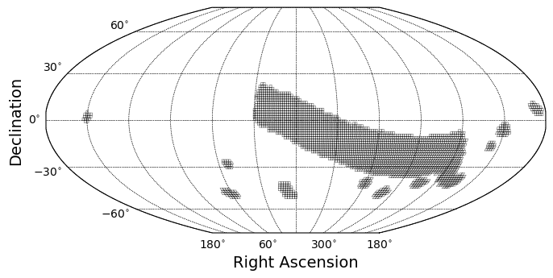

```python
fig, ax = plt.subplots(figsize=(8, 6))
sp = skyproj.McBrydeSkyproj(ax=ax)
for vertices in tracts_table['vertices_deg']:
    ras = vertices.transpose()[0]
    decs = vertices.transpose()[1]
    sp.draw_polygon(ras, decs, edgecolor='black', alpha=0.5, linewidth=0.5, facecolor=None)
sp.ax.set_xlabel("Right Ascension", fontsize=14)
sp.ax.set_ylabel("Declination", fontsize=14)
plt.show()
del sp
```

> **Figure 10:** All of the DP2 tracts for which deep coadd images will exist, in any filter.

Create a plot that is similar to the one above, but for only tracts that will have an $r$-band deep coadd image.

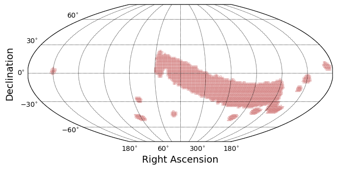

```python
show_filter = 'r'
fig, ax = plt.subplots(figsize=(8, 6))
sp = skyproj.McBrydeSkyproj(ax=ax)
for i, vertices in enumerate(tracts_table['vertices_deg']):
    flist = str(tracts_table['filters_list'][i])
    if flist.find(show_filter) >= 0:
        ras = vertices.transpose()[0]
        decs = vertices.transpose()[1]
        sp.draw_polygon(ras, decs, edgecolor=filter_colors[show_filter],
                        alpha=0.5, linewidth=0.5, facecolor=None)
sp.ax.set_xlabel("Right Ascension", fontsize=14)
sp.ax.set_ylabel("Declination", fontsize=14)
plt.show()
del sp, show_filter
```

> **Figure 11:** The DP2 tracts for which $r$-band deep coadd images will exist.

Create a plot that is similar to the one above, but only for tracts with $r$-band for which the $r$-band magnitude limit is $>23$ mag.

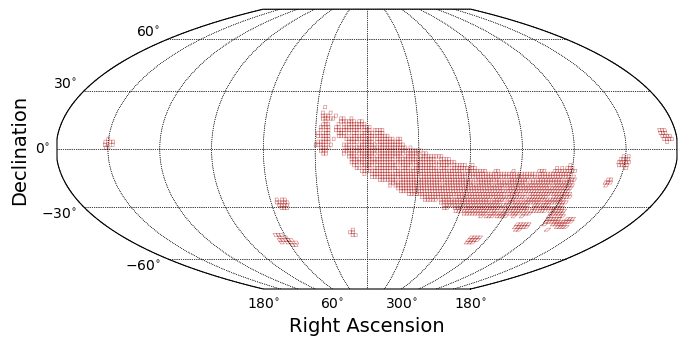

```python
show_filter = 'r'
fig, ax = plt.subplots(figsize=(8, 6))
sp = skyproj.McBrydeSkyproj(ax=ax)
for i, vertices in enumerate(tracts_table['vertices_deg']):
    flist = str(tracts_table['filters_list'][i])
    if flist.find(show_filter) >= 0:
        if (tracts_table['psf_maglim_r'][i] > 23.0):
            ras = vertices.transpose()[0]
            decs = vertices.transpose()[1]
            sp.draw_polygon(ras, decs, edgecolor=filter_colors[show_filter],
                            alpha=0.5, linewidth=0.5, facecolor=None)
sp.ax.set_xlabel("Right Ascension", fontsize=14)
sp.ax.set_ylabel("Declination", fontsize=14)
plt.show()
del sp, show_filter
```

> **Figure 12:** The DP2 tracts for which $r$-band deep coadd images will exist, and have a magnitude limit fainter than 23 mag.

## 4. Is my object in DP2?

Recall the **caveat** from Section 1: these temporary, preliminary metadata files include all visits and tracts that were processed, and might include those that do not, ultimately, pass data validation or produce science-quality data products.

> **Caveat:** coordinates that are *near the edge* of a visit or tract might seem to be included in DP2 using the code below, but this is not a guarantee that there will be high-quality data exactly at that location.

Define two target coordinates. Based on the figures above, the first one will, but the second one will not, be included in DP2.

```python
target1_ra, target1_dec = 300.0, -15.0
target2_ra, target2_dec = 300.0, +15.0
```

Convert the targets' coordinates to the `astropy` `SkyCoord` class.

```python
c1 = SkyCoord(target1_ra, target1_dec, unit="deg")
c2 = SkyCoord(target2_ra, target2_dec, unit="deg")
```

### 4.1. Visits

Define the radius of a visit. This is the radius of the LSSTCam's FOV in degrees.

```python
radius = 1.75
```

Convert the visits' coordinates to the `astropy` `SkyCoord` class.

```python
vc = SkyCoord(visits_table['ra'], visits_table['dec'], unit="deg")
```

Calculate the on-sky separations between each target and all of the visits.

```python
s1 = vc.separation(c1)
s2 = vc.separation(c2)
```

Sum up the number of visits that are within the LSSTCam radius of each target, and print the result.

```python
tx1 = np.where(s1.degree < radius)[0]
tx2 = np.where(s2.degree < radius)[0]
print('Number of visits containing')
print('  target 1: ', len(tx1))
print('  target 2: ', len(tx2))
del tx1, tx2
```

```
Number of visits containing
  target 1:  49
  target 2:  0
```

As expected, target 1 has overlapping visits and target 2 does not.

```python
del radius, vc, s1, s2
```

### 4.2. Tracts

For the first tract in the table, get the vertices (corners), convert them to `SkyCoord`, and create a `PolygonSkyRegion` for the tract.

```python
row = 0
vertices = tracts_table['vertices_deg'][row]
ras = vertices.transpose()[0]
decs = vertices.transpose()[1]
vertices_sc = SkyCoord(ras, decs, unit='deg')
region_sky = PolygonSkyRegion(vertices=vertices_sc)
print(region_sky)
del row, vertices, ras, decs, vertices_sc
```

```
Region: PolygonSkyRegion
vertices: <SkyCoord (ICRS): (ra, dec) in deg
    [(  1.35783962, -52.14776467), (358.64206988, -52.14776363),
     (358.6905163 , -50.48166585), (  1.30939644, -50.48166683)]>
```

Define a third target coordinate that is within the first tract's vertices, and convert it to a `SkyCoord`.

```python
target3_ra, target3_dec = 359.0, -51.0
c3 = SkyCoord(target3_ra, target3_dec, unit="deg")
```

Use the `contains` method for the `region_sky` to check if any of targets 1, 2, or 3 are within the first tract. This method requires that a generic World Coordinate System (WCS) be passed, so create one first.

The first two coordinates will not be, but the third was especially defined to be within the first tract. The output will be "False, False, True".

```python
wcs = WCS(naxis=2)
wcs.wcs.ctype = ["RA---TAN", "DEC--TAN"]
print(region_sky.contains(c1, wcs))
print(region_sky.contains(c2, wcs))
print(region_sky.contains(c3, wcs))
```

```
[False]
[False]
[ True]
```

For each of the three coordinates, check whether any tracts overlap. Tally the number of overlapping tracts and print the number.

For targets 1, 2, and 3, the resulting tally will be 1, 0, and 1.

```python
for c, coord in enumerate([c1, c2, c3]):
    tally = 0
    for row in range(len(tracts_table)):
        vertices = tracts_table['vertices_deg'][row]
        ras = vertices.transpose()[0]
        decs = vertices.transpose()[1]
        vertices_sc = SkyCoord(ras, decs, unit='deg')
        region_sky = PolygonSkyRegion(vertices=vertices_sc)
        if region_sky.contains(coord, wcs):
            tally += 1
        del vertices, ras, decs, vertices_sc, region_sky
    print('For target', c+1, 'the number of overlapping tracts =', tally)
del tally
```

```
For target 1 the number of overlapping tracts = 1
For target 2 the number of overlapping tracts = 0
For target 3 the number of overlapping tracts = 1
```

```python
del c1, c2, c3
```

### 4.3. Sky distribution

Combine the visits and tracts maps into a single plot, and show the locations of the three targets.

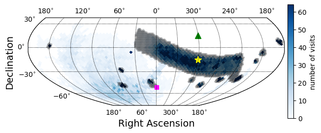

```python
fig, ax = plt.subplots(figsize=(8, 6))
sp = skyproj.McBrydeSkyproj(ax=ax)
vras = np.asarray(visits_table['ra'], dtype='float')
vdecs = np.asarray(visits_table['dec'], dtype='float')
sp.draw_hpxbin(vras, vdecs, nside=19, alpha=1, cmap='Blues', vmin=0)
sp.draw_colorbar(label='number of visits', fontsize=10, pad=0.01, shrink=0.5)
for vertices in tracts_table['vertices_deg']:
    ras = vertices.transpose()[0]
    decs = vertices.transpose()[1]
    sp.draw_polygon(ras, decs, edgecolor='black', alpha=0.5, linewidth=0.5, facecolor=None)
    del ras, decs
sp.ax.plot(target1_ra, target1_dec, '*', ms=10, color='yellow')
sp.ax.plot(target2_ra, target2_dec, '^', ms=8, color='green')
sp.ax.plot(target3_ra, target3_dec, 's', ms=6, color='magenta')
sp.ax.set_xlabel("Right Ascension", fontsize=14)
sp.ax.set_ylabel("Declination", fontsize=14)
plt.show()
del sp, vras, vdecs
```

```python
del target1_ra, target2_ra, target3_ra, target1_dec, target2_dec, target3_dec
```

## 5. Which DP1 fields are in DP2?

Define the [DP1 field centers](https://dp1.lsst.io/overview/observations.html#field-centers).

```python
dp1_field_names = ['47 Tuc globular cluster',
                   'Low Ecliptic Latitude Field',
                   'Fornax Dwarf Spheroidal Galaxy',
                   'Extended Chandra Deep Field South',
                   'Euclid Deep Field South',
                   'Low Galactic Latitude Field',
                   'Seagull Nebula']
dp1_field_ras = [6.02, 37.86, 40.00, 53.13, 59.10, 95.00, 106.23]
dp1_field_decs = [-72.08, 6.98, -34.45, -28.10, -48.73, -25.00, -10.51]
```

### 5.1. Visits

Print the number of visits, in any filter, that overlap the central coordinates of each DP1 field.

```python
radius = 1.75
vc = SkyCoord(visits_table['ra'], visits_table['dec'], unit="deg")
for i in range(len(dp1_field_names)):
    field_coord = SkyCoord(dp1_field_ras[i], dp1_field_decs[i], unit="deg")
    separations = vc.separation(field_coord)
    tx = np.where(separations.degree < radius)[0]
    print('%-35s %4i' % (dp1_field_names[i], len(tx)))
    del field_coord, separations, tx
del radius, vc
```

```
47 Tuc globular cluster                8
Low Ecliptic Latitude Field            0
Fornax Dwarf Spheroidal Galaxy         3
Extended Chandra Deep Field South    294
Euclid Deep Field South              175
Low Galactic Latitude Field           11
Seagull Nebula                         3
```

### 5.2. Tracts

Print whether there is a deep coadd tract that overlaps the central coordinates of each DP1 field.

```python
for i in range(len(dp1_field_names)):
    field_coord = SkyCoord(dp1_field_ras[i], dp1_field_decs[i], unit="deg")
    overlap = False
    for row in range(len(tracts_table)):
        vertices = tracts_table['vertices_deg'][row]
        ras = vertices.transpose()[0]
        decs = vertices.transpose()[1]
        vertices_sc = SkyCoord(ras, decs, unit='deg')
        region_sky = PolygonSkyRegion(vertices=vertices_sc)
        if region_sky.contains(field_coord, wcs):
            overlap = True
        del vertices, ras, decs, vertices_sc, region_sky
    print('%-35s %5s' % (dp1_field_names[i], overlap))
    del field_coord, overlap
```

```
47 Tuc globular cluster             False
Low Ecliptic Latitude Field         False
Fornax Dwarf Spheroidal Galaxy      False
Extended Chandra Deep Field South    True
Euclid Deep Field South              True
Low Galactic Latitude Field         False
Seagull Nebula                      False
```

### 5.3. Sky distribution

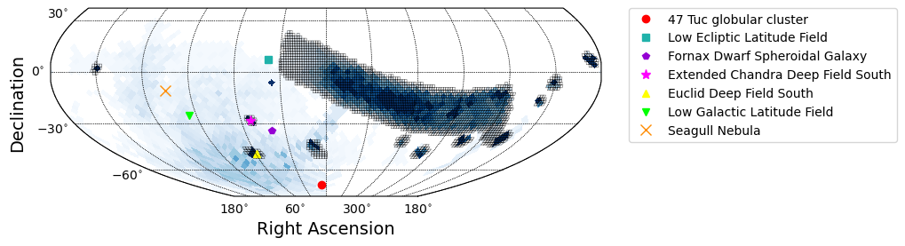

```python
dp1_field_symbols = ['o', 's', 'p', '*', '^', 'v', 'x']
dp1_field_symsizes = [6, 6, 6, 8, 6, 6, 8]
dp1_field_colors = ['red', 'lightseagreen', 'darkviolet',
                    'magenta', 'yellow', 'lime', 'darkorange']
fig, ax = plt.subplots(figsize=(8, 6))
sp = skyproj.McBrydeSkyproj(ax=ax)
vras = np.asarray(visits_table['ra'], dtype='float')
vdecs = np.asarray(visits_table['dec'], dtype='float')
sp.draw_hpxbin(vras, vdecs, nside=19, alpha=1, cmap='Blues', vmin=0)
for vertices in tracts_table['vertices_deg']:
    ras = vertices.transpose()[0]
    decs = vertices.transpose()[1]
    sp.draw_polygon(ras, decs, edgecolor='black', alpha=0.5, linewidth=0.5, facecolor=None)
    del ras, decs
for i in range(len(dp1_field_names)):
    sp.ax.plot(dp1_field_ras[i], dp1_field_decs[i], dp1_field_symbols[i], ms=dp1_field_symsizes[i],
               color=dp1_field_colors[i], label=dp1_field_names[i])
sp.ax.set_xlabel("Right Ascension", fontsize=14)
sp.ax.set_ylabel("Declination", fontsize=14)
sp.ax.legend(bbox_to_anchor=(1.05, 1), loc='upper left', borderaxespad=0.)
plt.show()
del sp, vras, vdecs
```